# 0. data, functions

There is one main function, `fdl`, used to make the figures. Typically, the data used will be imported as below, but any data with the required variables will work; see examples.

Use `fdl` to plot by discrete (eg, cluster ID) or continuous (eg, expression level) variable; use `fdl_split` to compare variable by group. `km` will crudely allow us to isolate some points.

```r
#' Plot force-directed layout
#'
#' @param data a data frame with at least two columns, "X" and "Y", of
#' coordinates, usually the exported force-directed layout data
#' @param group the variable to color by
#' @param legend an optional list of arguments passed to legend or FALSE
#' for no legend
#' @param col,from,reset_par,add not important
#'
#' @examples
#' x <- setNames(iris, c('X', 'Y', 'PL', 'PW', 'Group'))
#' par(mfrow = c(2,2))
#' fdl(x, 'Group')
#' fdl(x, 'PL')
#' fdl(x, 'PW', legend = list(title = 'Petal width', horiz = TRUE, bty = 'n'))
#' fdl(x, 'PW', FALSE, 'grey50')

fdl <- function(data, group = 'ClusterID', legend = list(),
                col = NULL, from = NULL, reset_par = TRUE, add = FALSE) {
  ## interpolate colors based on continuous values
  interp <- function(x, col, alpha = FALSE, n = 1e5L,
                     fr = NULL, to = 0:1) {
    fr <- if (is.null(fr))
      range(x, na.rm = TRUE) else fr
    to <- to[1:2] * if (alpha) 1 else n
    x  <- (x - fr[1L]) / diff(fr) * diff(to) + to[1L]

    if (alpha)
      Vectorize(adjustcolor)(col[1L], alpha.f = x)
    else colorRampPalette(col)(n + 1L)[as.integer(x) + 1L]
  }

  var <- if (is.null(group))
    'ClusterID'
  else if (length(var <- grep(group, names(data), value = TRUE)) > 1L)
    grep(sprintf('\\b%s\\b', group), names(data), value = TRUE)
  else if (!length(var))
    'ClusterID'
  else var

  data <- data[order(data[, var]), ]
  fvar <- as.factor(data[, var])

  ## guess if data is continuous or discrete
  ok <- is.factor(data[, var]) ||
    is.character(data[, var]) ||
    all(round(data[, var]) == data[, var])

  colors <- if (!ok)
    c('blue', 'cyan', 'green', 'yellow', 'red') else 'grey50'
  if (!is.null(col))
    colors <- c('transparent', col)
  nc <- seq_along(colors)

  op <- par(mar = c(0, 0, 0, 0))
  if (reset_par)
    on.exit(par(op))

  if (!add)
    plot(Y ~ X, data, type = 'n', ann = FALSE, axes = FALSE, bty = 'n')

  if (is.null(group))
    points(Y ~ X, data, pch = '.', cex = 2,
           col = adjustcolor(colors[1L], alpha.f = 0.5))
  else
    points(Y ~ X, data, pch = '.', cex = 2,
           col = if (ok) fvar else interp(data[, var], colors, fr = from))

  if (!identical(legend, FALSE) && !is.null(group)) {
    largs <- list(
      x = 'topright', pch = 16L, title = gsub(':.*', '', var),
      col = if (ok)
        seq_along(levels(fvar)) else colors,
      legend = if (ok)
        levels(fvar) else
          sprintf('%.1f', quantile(data[, var], (nc - 1L) / diff(range(nc))))
    )
    do.call('legend', modifyList(largs, legend))
  }

  invisible(NULL)
}

#' Split fdl by group
#'
#' For each unique split, points are colored by "group" or grey if identified
#' by another split.
#'
#' @param data,group,legend,reset_par see fdl
#' @param split variable to split figures
#'
#' @examples
#' x <- setNames(iris, c('X', 'Y', 'PL', 'PW', 'Group'))
#' par(mfrow = c(1,3))
#' fdl_split(x, 'PW', 'Group')

fdl_split <- function(data, group = 'ClusterID', split = 'Group',
                      legend = list()) {
  sp <- split(data, data[, split])
  gr <- grep(sprintf('\\b%s\\b', group), names(data))
  xr <- range(data[, gr], na.rm = TRUE)

  op <- par(oma = c(0,0,0,0))
  on.exit(par(op))

  lapply(seq_along(sp), function(ii) {
    x <- sp[[ii]]

    fdl(data, group, FALSE, 'grey50', xr)
    par(new = TRUE)
    fdl(x, group, FALSE, NULL, xr, FALSE, TRUE)
    mtext(names(sp)[ii], at = grconvertX(0, 'nfc'),
          adj = -1, line = -2, font = 2L, cex = 1.5)
  })

  cc <- c('blue', 'cyan', 'green', 'yellow', 'red')
  nc <- seq_along(cc)
  largs <- list(
    x = 'topright', pch = 16L, title = gsub(':.*', '', group), xpd = NA,
    col = cc,
    legend = sprintf('%.1f', quantile(data[, gr], (nc - 1L) / diff(range(nc))))
  )
  do.call('legend', modifyList(largs, legend))

  invisible(NULL)
}

#' Crudely identify points of a cluster using k-means
#'
#' @param data a data frame with at least two columns, "X" and "Y", of
#' coordinates, usually the exported force-directed layout data
#' @param centers number of clusters
#' @param spider,hull logical; types of ordination diagrams to display
#' @param groups optional vector of cluster(s) to draw
#' @param col color for the diagrams
#'
#' @examples
#' x <- setNames(iris[, 1:2], c('X', 'Y'))
#' par(mfrow = c(1,2))
#' plot(x)
#' cl <- km(x, 5)
#' points(x, col = cl$cluster)
#'
#' plot(x)
#' km(x, 5, groups = 4, col = 4)

km <- function(data, centers = length(unique(data$ClusterID)),
               spider = TRUE, hull = TRUE, groups = NULL, col = 'grey') {
  suppressPackageStartupMessages(
    require('vegan', character.only = TRUE, quietly = TRUE)
  )

  `%||%` <- function(x, y) if (is.null(x)) y else x

  set.seed(1)
  xy <- as.matrix(data[, c('X', 'Y')])
  km <- kmeans(xy, centers, 1e5L)
  cl <- factor(km$cluster)

  if (spider)
    ordispider(xy, factor(km$cluster, groups %||% levels(cl)),
               label = TRUE, col = adjustcolor(col, alpha.f = 0.1))
  if (hull)
    ordihull(xy, factor(km$cluster, groups %||% levels(cl)),
             lty = 'dashed', col = col)

  invisible(km)
}
```

These data were exported to csv in x-shift after clustering and plotting a force-directed layout. Additionally, my files were named by group, A or B, but this can be added manually to the data by file name.

```r
## read in fcs data after import (not necessary)
# dat <- as.data.frame(readr::read_csv('data/data.csv'))

## read in cluster data after clustering is complete
clust <- as.data.frame(readr::read_csv('../data/cluster.csv'))
clust <- within(clust, {
  Filename <- `File Name`
  Group    <- gsub('^(.)|.', '\\U\\1', Filename, perl = TRUE)
})

## read in force-directed layout coordinates after FDL is complete
coords <- as.data.frame(readr::read_delim('../data/coords.csv', ';'))

coords <- within(coords, {
  ## data reflected about y-axis on mac but not windows?
  Y <- Y * -1
})


datm <- merge(coords, clust, by = c('Filename', 'EventID'))


## rescale continuous data for better figures because why not
idx <- grep(':', names(datm), value = TRUE)
datm[, idx] <- lapply(datm[, idx], function(x) log2(x + 1))
```

# 1. Identify cytotoxic T cells (also called CD8+ T cells; they express CD3 and CD8, but not CD4) in all samples.

Visually inspect the figures for expression levels of CD3, CD4, and CD8. Use `km` to create several clusters (eg, as many clusters as x-shift found), then pick out one or more to highlight in the final figure.

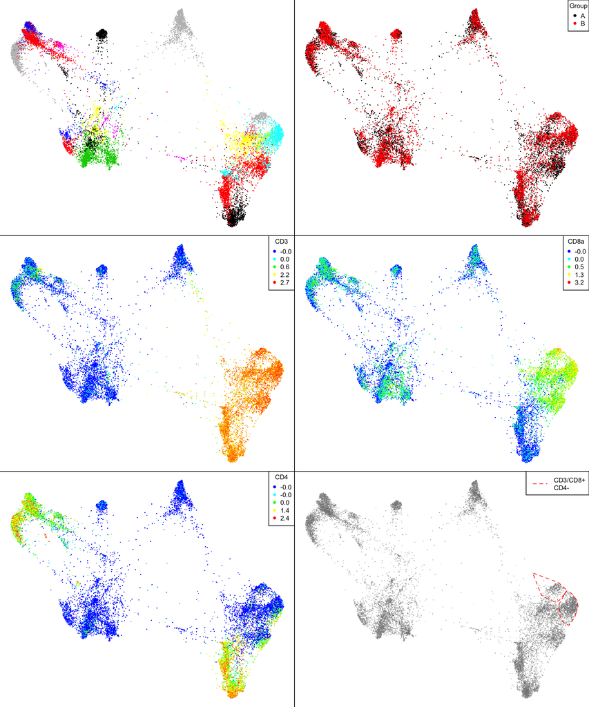

```r
par(mfrow = c(3,2))
fdl(datm, 'ClusterID', FALSE)
fdl(datm, 'Group')

fdl(datm, 'CD3')
fdl(datm, 'CD8a')
fdl(datm, 'CD4')

fdl(datm, NULL)

## choose groups to highlight manually
# km(datm)
## groups 6, maybe 16, look like CD8+ t-cells

km(datm, groups = c(6, 16), spider = FALSE, col = 'red')
legend('topright', legend = 'CD3/CD8+\nCD4-', col = 'red', lty = 2L)

# fdl(datm, 'PD')

abline(h = grconvertY(1:2 / 3, 'ndc'), v = grconvertX(.5, 'ndc'), xpd = NA)
```

# 2. Determine whether there are differences in expression of PD-1, Tim-3, LAG-3, CTLA-4, ICOS, 4-1BB, OX-40, Ki-67, HLA-DR, and CD38 on CD8+ T cells between patient Groups A and B.

X-shift can do enrichment analyses, but we will inspect this visually using the same function as above but splitting by group.

All points are plotted for each figure. On the left panel, only points belonging to patients in group A are colored by marker and grayed-out if belonging to patients in group B.

```r
wh <- c('PD', 'Tim', 'LAG', 'CTLA4', 'ICOS',
        '4-1BB', 'OX40', 'Ki-67', 'HLA', 'CD38')
par(mfrow = c(1,2))
for (ii in wh) {
  fdl_split(datm, ii)
  abline(v = grconvertX(0.5, 'ndc'), xpd = NA)
  box('outer')
}
```

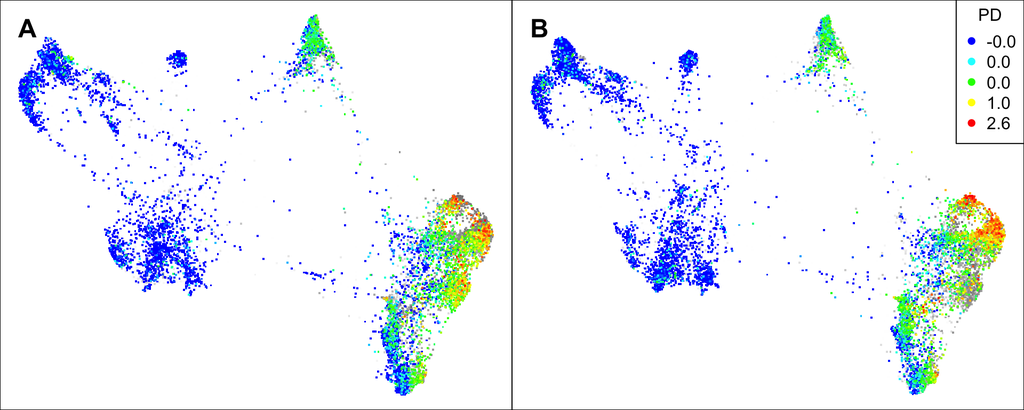

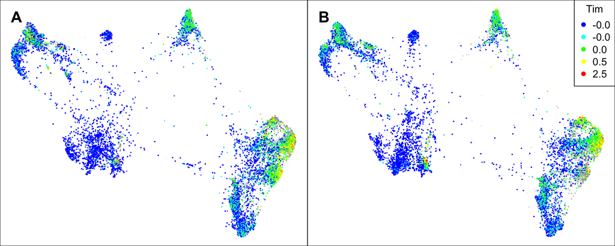

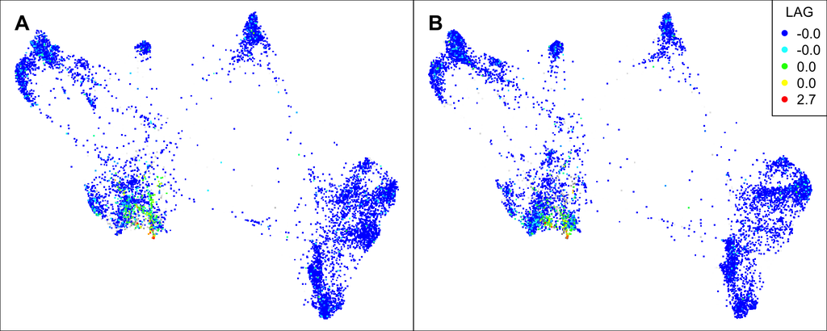

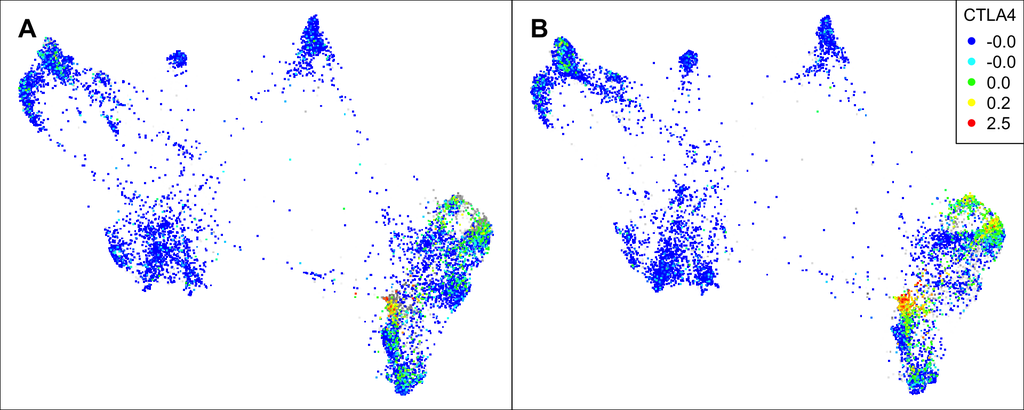

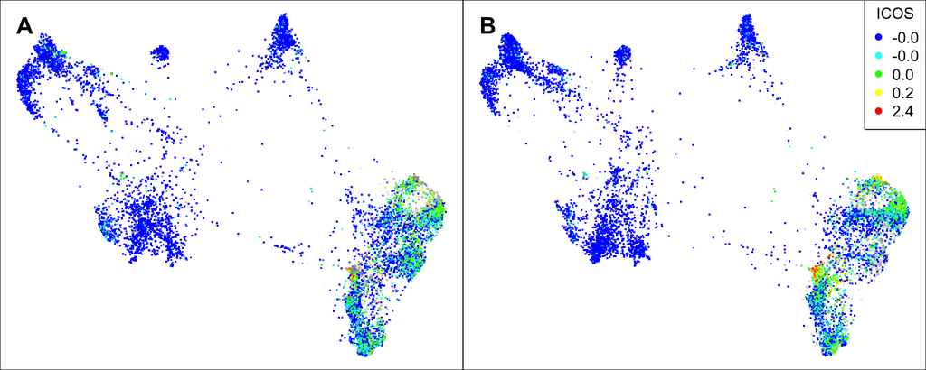

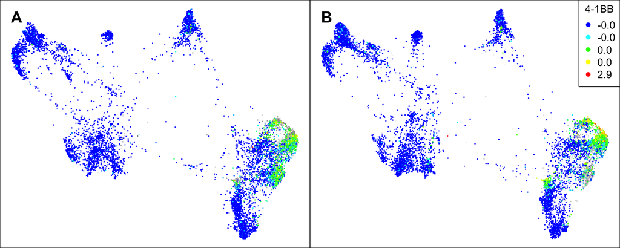

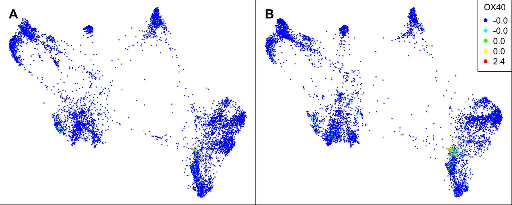

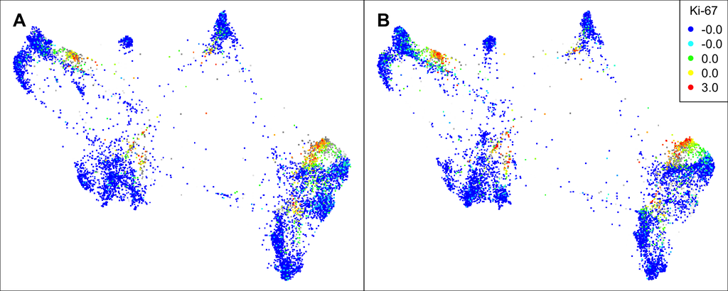

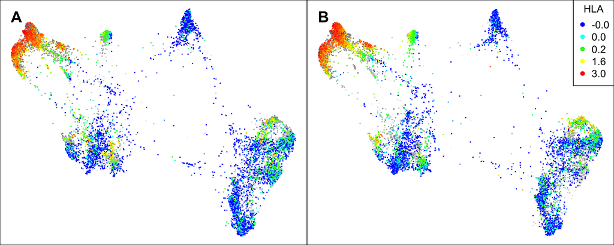

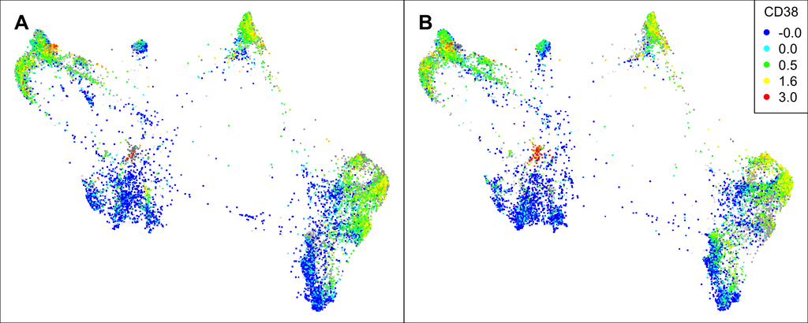